# Temperature modeling for aquaculture

PURA acuicultura

2/24/2021

## Introduction

Being ectothermic, fish are subject to the external temperature fluctuations of the environments in which they live. Variance exists in both temperature tolerance and temperature optima among fish species. At the temperature optima for a given species, growth potential is maximal. Appetite, which also varies with temperature, is also maximal at the temperature optima. Away from the temperature optima, both feeding and growth are reduced though not necessarily to the same extent in relation to whether temperatures are above or below the optima.

Its dependence of growth makes temperature an integral part of nearly any fish growth model. Temperature varies diurnally, annually, and over multi-year cycles. While diurnal fluctuations can be vitally important to many aspects of practical aquaculture management, they are ignored in this discussion given their contribution to a daily cumulative growth model is negligible. Annual variation in temperature is driven by seasonal variation. As such, tropical conditions (NB: Tilapia) can see significantly lower annual variation in temperature than temperate regions (NB: Salmon). Multi-year variation in temperature can arise from a number of sources. While variable length climatic oscillations such as El nino is a naturally occurring example, global warming is an example of anthropogenic temperature variance.

The development of temperature models for fish growth modeling is discussed here. Specific focus is on generating modeling frameworks that can be easily adjusted to the varying geographies over which aquaculture is practiced.

```r
library(tidyverse)
```

## Annual variation

The temperature models developed here are conceptually different than the cumulative daily growth model developed earlier. If we remember, the growth model started with actual fish growth results and then used mathematics to describe the relationships between time and fish weight. Here, we work in the opposite order and start by using mathematics and finish with ‘modeled’ temperature profiles for typical aquaculture environments. The process is similar but subtly different. For example, while experimental results previously dictated the independent factors of our growth model, for our temperature models we have the freedom to select the independent factors most suited to our modeling goals. In fact, selecting these factors is the most logical place to start.

```r
date_ini <- as.Date("2010-01-01")
date_fin <- as.Date("2020-12-31")
temp_mean <- 25
temp_var <- 2
```

```r
DATE <- seq(date_ini, date_fin, by = 1)
DAY <- 1:length(DATE)
df_temp <- data.frame(DATE, DAY)
```

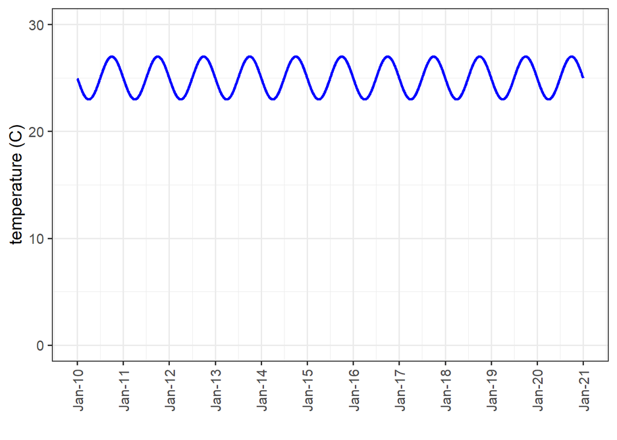

```r
df_temp %>%
  mutate(DAY_rad = -1 * DAY / 365.25 * 2 * pi) %>%
  mutate(TEMP = temp_mean + temp_var * sin(DAY_rad)) %>%
  ggplot(aes(x = DATE, y = TEMP)) +
  geom_line(color = "blue", size = 1) +
  scale_y_continuous(limits = c(0, 30)) +
  scale_x_date(date_breaks = "1 year",
               date_labels = "%b-%y") +
  xlab("") +
  ylab("temperature (C)") +
  theme_bw(base_size = 14) +
  theme(axis.text.x = element_text(angle = 90,
                                   vjust = 0.5,
                                   hjust = 1))
```